# DATA 602 - Introduction to Hypothesis Testing

### Back to the Data

Let’s find the difference between the prices of cameras between stores **JR** and **BH** by creating a new variable called **Diff** and attaching this new variable onto the **Cameras** data.

Let’s think of the price of camera $i$ at the JR-store as $x_{JR,i}$ and the price of the same camera at store $BH$ as $x_{BH, i}$.

```r
Cameras = Cameras %>%
  mutate(Diff = JR - BH)
head(Cameras, 4)
```

|  | ID | Item | JR | BH | Diff |
| --- | --- | --- | --- | --- | --- |
| 1 | 1 | Canon PowerShot A3000 | 129.99 | 149.99 | -20.00 |
| 2 | 2 | Canon PowerShot A495 | 99.88 | 96.95 | 2.93 |
| 3 | 3 | Casio EX-FC150 | 241.88 | 241.19 | 0.69 |
| 4 | 4 | Kodak EasyShare C142 | 74.94 | 79.59 | -4.65 |

Below is both a histogram and a boxplot of the $d_{i}$s, the difference in camera prices between these two stores.

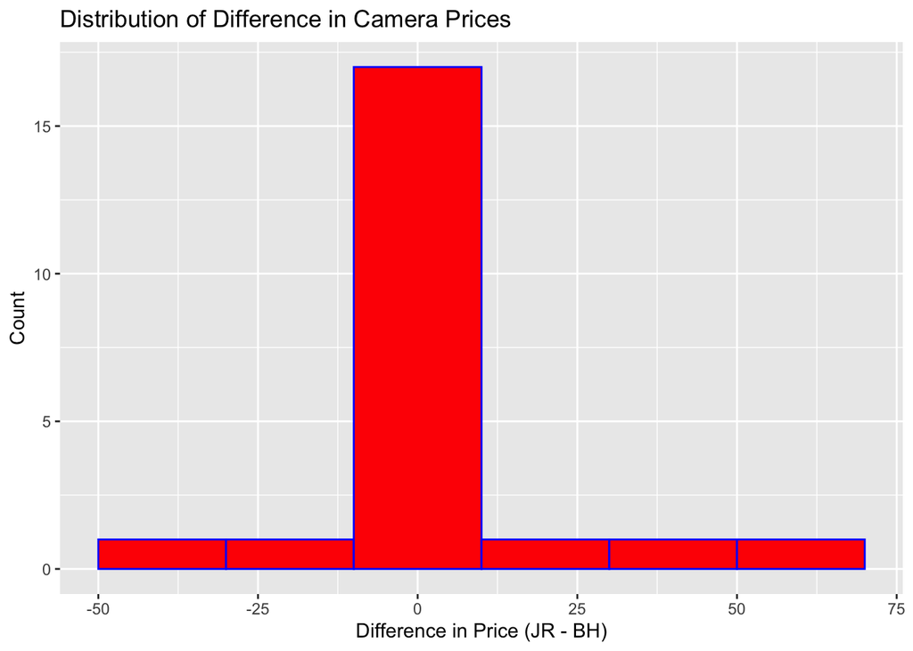

```r
ggplot(data=Cameras, aes(x = Diff)) + geom_histogram(col='blue', fill='red', binwidth=20) + xlab("Difference in Price (JR - BH)") + ylab("Count") + ggtitle("Distribution of Difference in Camera Prices")
```

A boxplot is perhaps a more-telling visual display of these data.

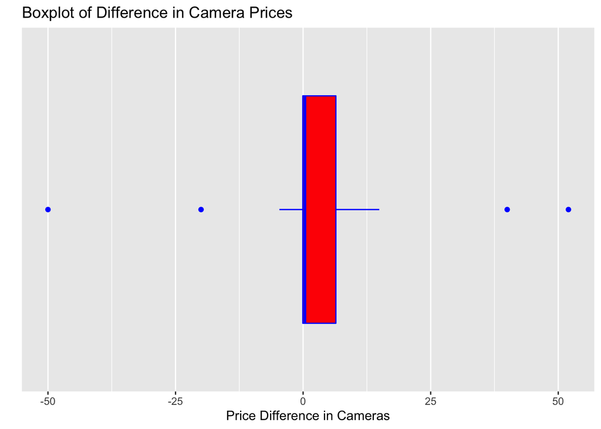

```r
ggplot(data=Cameras, aes(x = "var", y = Diff)) + geom_boxplot(col='blue', fill= 'red') + xlab("") + ylab("Price Difference in Cameras") + scale_x_discrete(breaks=NULL) + coord_flip() + ggtitle("Boxplot of Difference in Camera Prices")
```

**Time to Play 4:** Let’s not forget the motivation for this data collection in the first instance. You wish to see if there is a difference, on average, between these two stores with respect to the price of a camera.

1. Ponder the *differences* that have been computed, the $d_{i}$s, and population of differences. If there is no difference, on average, between the price of a camera at store JR and store BH, what is the value of the mean of this population of differences?
   **Answer:**
   $$\begin{aligned}
   {\rm H}_{0}: \mu_{d} = & 0 \hspace{0.2in} ({\rm difference\:\:in\:\:camera\:\:prices\:\:on\:\:average\:\:are\:\:the\:\:same}) \\
   {\rm H}_{A}: \mu_{d} \ne & 0 \hspace{0.2in} ({\rm difference\:\:in\:\:camera\:\:prices\:\:on\:\:average\:\:are\:\:NOT\:\:the\:\:same}) \\
   \end{aligned}$$
2. Compute the mean of the difference and the standard deviation of the differences, $\overline{d}$ and $S_{d}$. Notice the value of $\overline{d}$, what does this say about the average of the differences computed and previously visualized?  
   **Answer:** Using the `favstats` command:

```r
favstats(~ Diff, data = Cameras)
```

|  | min | Q1 | median | Q3 | max | mean | sd | n | missing |
| --- | --- | --- | --- | --- | --- | --- | --- | --- | --- |
|  | -50 | -0.055 | 0.365 | 6.42 | 52 | 2.805455 | 18.95815 | 22 | 0 |

3. Compute the value of the Student’s $t$ Test Statistic, just as was done in Example 1. Simply replace $\overline{X}$ with $\overline{d}$ and $S$ with $S_{d}$. Ensure you incorporate the value of the mean difference $\mu_{d}$ that you are assuming to be true in your null hypothsis. Also, what is your $n$ equal to here? Is $n = 44$ or is $n = 22$?
   **Answer:**
   $$T_{Obs} = \frac{\overline{d} - \mu_{0}}{\frac{S_{d}}{\sqrt{n}}} = \frac{2.805455 - 0}{\frac{18.95815}{\sqrt{22}}} = 0.69409$$
4. Now, use `t.test` to generate the value of $T_{Obs}$, the $P$-value, and the 95% confidence interval for $\mu_{d}$.  
   **Answer:**

```r
t.test(~ Diff, mu=0, alternative="two.sided", conf.level = 0.95, data = Cameras)
```

```
##
##  One Sample t-test
##
## data:  Diff
## t = 0.69409, df = 21, p-value = 0.4952
## alternative hypothesis: true mean is not equal to 0
## 95 percent confidence interval:
##  -5.60012 11.21103
## sample estimates:
## mean of x
##  2.805455
```

From which,

$$T_{Obs} = 0.6941 \hspace{0.2in} P-\text{value} = P(T_{21} > 0.694)*2 = 0.4952$$

5. From the output in 4, provide the $P$-value. What does this $P$-value represent? What is your decision about the null hypothesis?  
   **Answer:** If the null hypothesis is true (and, on average, there is no difference in the price of a camera), then the chance/probability of another matched-pairs experimental design will produce stronger statisical evidence against the null hypothesis *than the current data/sample* is 0.4952.

### An Afterthought

The inferences made about the mean/average different in the price of cameras between store JR and store BH are made upon the *condition* that the differences follow a Normal distribution/can be modeled by the Normal probabilty model. Does this condition seem to be satisfied?  
Below is a Normal probablity plot of the differences $d_{i}$s.

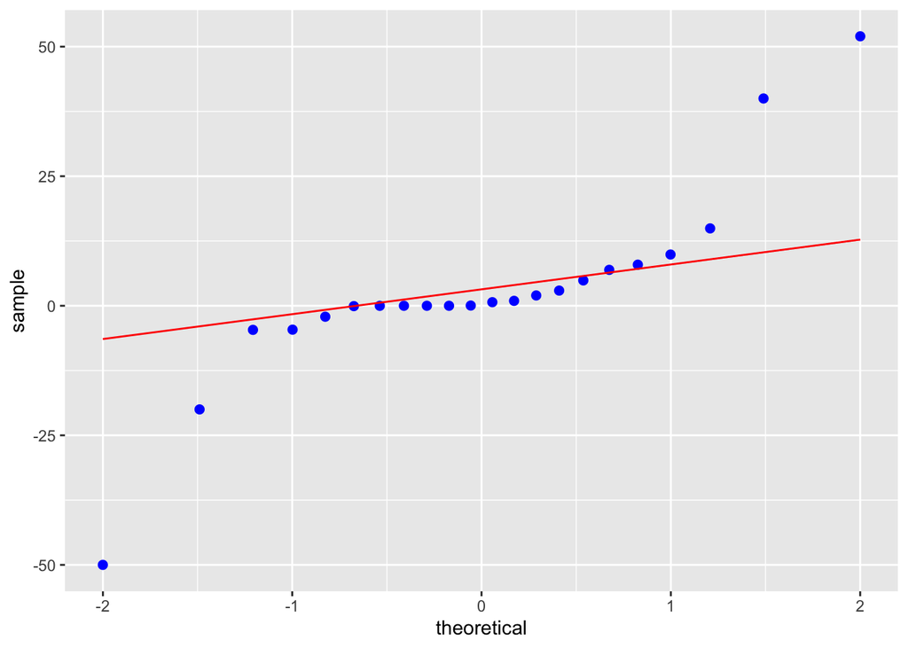

```r
ggplot(data=Cameras, aes(sample = Diff)) + stat_qq(size=2, col='blue') + stat_qq_line(col='red')
```

**Suppose these differences appeared to stray from the Normal Probability Model**?

If such were the case, one could simply create a bootstrap interval of the bootstrap statisic $\overline{d}$. Let’s take a look:

```r
nsims=1000
diffmean = numeric(nsims)
for(i in 1:nsims)
{
  diffmean[i] = mean(sample(Cameras$Diff, 22, replace=TRUE))
}
```

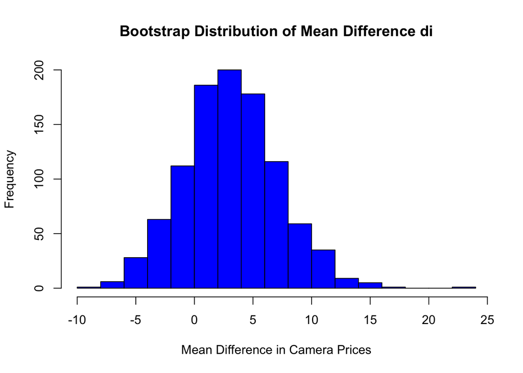

```r
hist(diffmean, xlab="Mean Difference in Camera Prices", col="blue", main="Bootstrap Distribution of Mean Difference di")
```

```r
quantile(diffmean, c(0.025, 0.975), data=Cameras)
```

```
##      2.5%     97.5%
## -4.664795 11.265705
```

[^1]: https://www.cbc.ca/news/canada/calgary/vote-compass-economy-1.5091293
[^2]: (http://angusreid.org/three-in-four-canadians-call-airlines-new-checked-baggage-fees-unacceptable-money-grab/)